# **Rapport statistique sur un jeu de données**

YIFEI WANG, M1 MIASHS-C2ES

2020-11-01

### **Description des données**

#### Dataset : `commute_mode` et `social`

#### Description

- L’influence des facteurs géographiques sur les habitudes de déplacement.
- Tableau 1 : `commute_mode`

  Introduction de facteurs sociaux et économiques tels que la taille de la ville et la localisation géographique des villes. Le tableau divise les villes en trois types en fonction de leur population résidente， divise les région par la localisation géographique des state.

| Nom de colonne | Description | Groupe |
| --- | --- | --- |
| state | Nom de state |  |
| city_size | La taille de la ville | small medium large |
| mode | Les types de déplacement | bike walk |
| percent | Les pourcentage de chaque type |  |
| state_region | La localisation géographique des state | West Northeast South North Central |

- Tableau 2 : `social`

  Introduction de facteurs sociaux et économiques tels que l’âge, le sexe, le nombre d’enfants, la salaire etc.

| Nom de colonne | Description |
| --- | --- |
| total_workers | Le nombre total de travailleurs |
| bike_percent | Le pourcentage de déplacement à vélo |
| walk_percent | Le pourcentage de déplacement à pied |
| other_percent | Le pourcentage de déplacement aux autres façons |

### **Traiter des données**

- Tableau : `social`

```r
social %>%
  slice(1:6) %>%
  pivot_longer(cols = !age & !total_workers &!other_percent,
               names_to = "Methode", values_to = "Percent") -> Age

social %>%
  slice(9:10) %>%
  rename("Sexe" = age) %>%
  pivot_longer(cols = !Sexe & !total_workers &!other_percent,
               names_to = "Methode", values_to = "Percent") -> Sexe

social %>%
  slice(22:24) %>%
  rename("Enfant" = age) %>%
  pivot_longer(cols = !Enfant & !total_workers &!other_percent,
               names_to = "Methode", values_to = "Percent") -> Enfant

social %>%
  slice(27:36) %>%
  rename("Salaire" = age) %>%
  pivot_longer(cols = !Salaire & !total_workers &!other_percent,
               names_to = "Methode", values_to = "Percent") -> Salaire
```

- Tableau : `commute_mode`

### **Questions**

#### Question 1 : *À quel âge les gens préfèrent-ils se rendre au travail à pied ou à vélo?*

1. Les taux de déplacement à vélo étaient les plus fréquents chez les travailleurs âgés de 16 à 24 ans, soit 1,0 %. Ils diminuent avec l’âge, le taux le plus bas (0,3 %) étant enregistré chez les travailleurs âgés de 55 ans et plus.
2. Les travailleurs âgés de 16 à 24 ans affichaient le taux le plus élevé de déplacements à pied pour se rendre au travail, soit 6,8 %. Le taux a fortement diminué pour atteindre 3,1 % des travailleurs de la tranche d’âge supérieure, puis est resté inférieur à 3 % pour toutes les tranches d’âge.

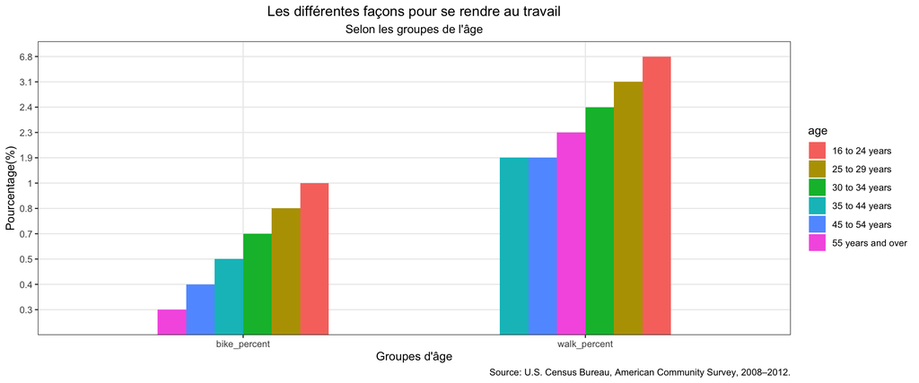

#### Question 2 : *Y a-t-il une différence entre les taux de déplacement à vélo ou à pied entre les hommes et les femmes?*

1. Aux États-Unis, les hommes qui se rendent au travail à pied ont un taux de 2,9 % et les femmes ont un taux de 2,8 %.
2. La différence entre les taux de déplacement à vélo des hommes et des femmes est plus prononcée que celle des taux de déplacement à pied. Avec 0,8 %, le taux de déplacement à vélo des hommes est plus de deux fois plus élevé que celui des femmes (0,3 %).

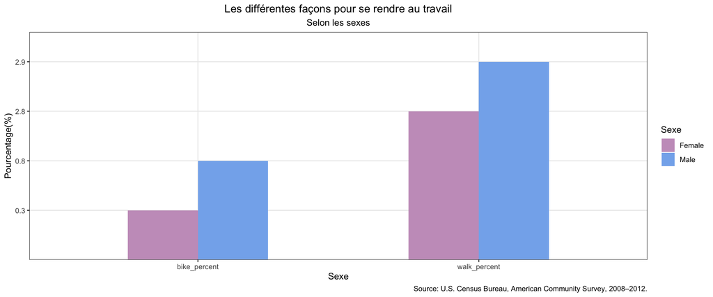

#### Question 3 : *Les travailleurs sans enfants préfèrent-ils se rendre au travail à pied ou à vélo ?*

- Les travailleurs sans enfants sont relativement plus susceptibles de se rendre au travail à pied (2.8%) ou à vélo (0.7%).

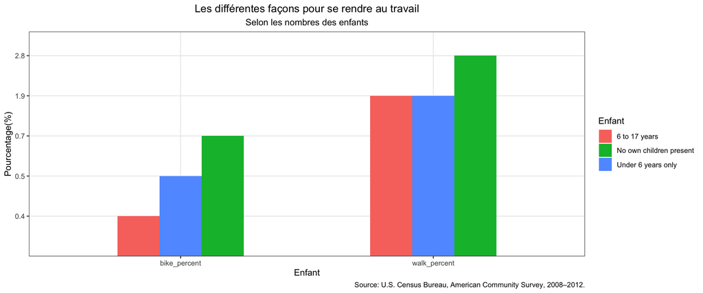

#### Question 4 : *Les personnes à salaires élevés sont moins susceptibles de se déplacer à vélo ou à pied ?*

- À mesure que les salaires augmentent, les taux de déplacement à pied et à vélo diminuent, mais s’inversent dans les deux catégories de sailaires les plus élevés.
- Les travailleurs à salaire faibles avaient des taux relativement élevés, reflétant probablement des taux plus faibles de possession d’une voiture. Et les travailleurs à salaire élevés ont une augmentation des taux, peut-être liée à la localisation géographique de leurs villes de résidence.

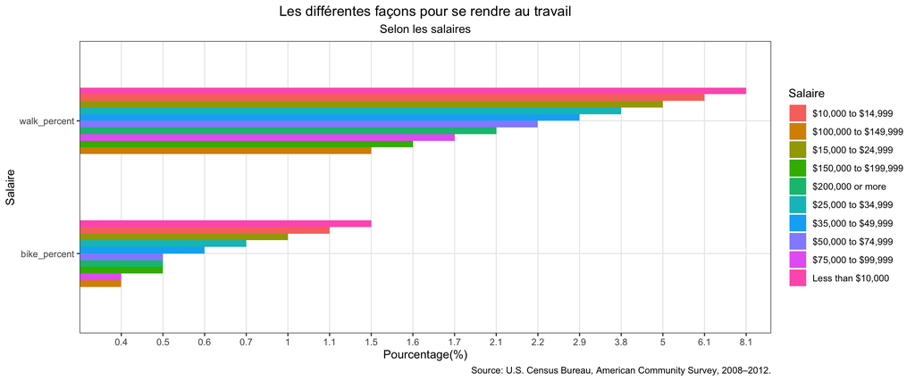

##### Question 5 :

不同社区和地区的步行和自行车出行率差异很大。当地的因素，如社区规模、设计、基础设施和气候，影响着每种交通方式的可用性、吸引力和可负担性。例如，在小城市，更多的潜在目的地年龄可能在自行车或步行的距离内，汽车交通可能相对较少，增加了非机动车旅行的吸引力10。

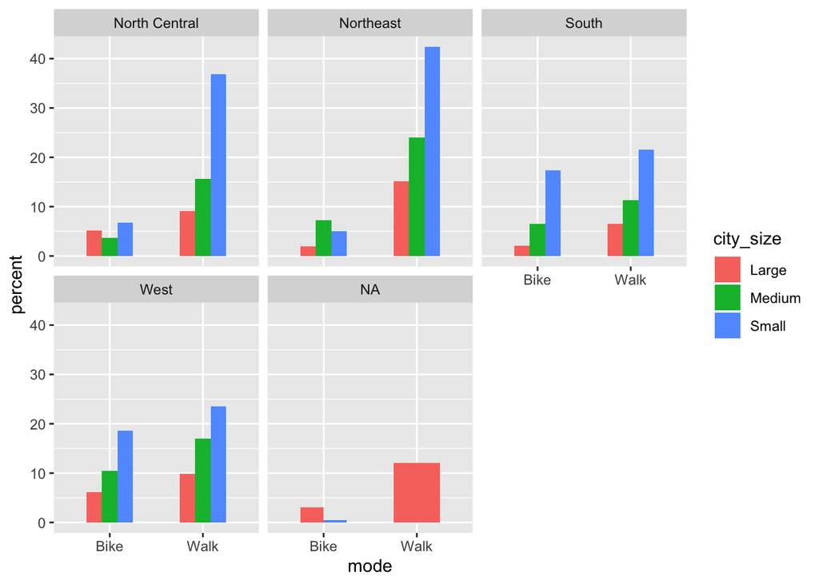

##### *Question 4:*

對於幾個地區來說，周邊郊區的非機動車旅行率相對較低，使得都市區的整體非機動車出行率低於中心城市。然而，许多较小的地方的步行或骑自行车的比率较高。

#### **Conclusion**

随着年龄的增长，自行车通勤率的下降可能与劳动者的体能、居住地、收入等因素有关。